# Fitting Normal Distribution

coop711

2016-03-14

## Data

### 책에서

```r
library(pander)
library(knitr)
```

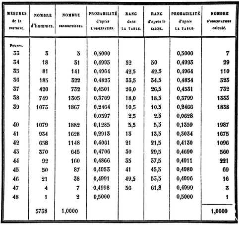

[figure not shown]

### 돗수분포표

- 케틀레가 작성한 스코틀랜드 군인 5738명의 가슴둘레(인치) 분포표를 옮기면

```r
chest <- 33:48
freq <- c(3,18,81,185,420,749,1073,1079,934,658,370,92,50,21,4,1)
(chest.table <- data.frame(Chest=chest, Freq=freq))
```

```
##    Chest Freq
## 1     33    3
## 2     34   18
## 3     35   81
## 4     36  185
## 5     37  420
## 6     38  749
## 7     39 1073
## 8     40 1079
## 9     41  934
## 10    42  658
## 11    43  370
## 12    44   92
## 13    45   50
## 14    46   21
## 15    47    4
## 16    48    1
```

```r
str(chest.table)
```

```
## 'data.frame':    16 obs. of  2 variables:
##  $ Chest: int  33 34 35 36 37 38 39 40 41 42 ...
##  $ Freq : num  3 18 81 185 420 ...
```

```r
pander(chest.table)
```

| Chest | Freq |
| --- | --- |
| 33 | 3 |
| 34 | 18 |
| 35 | 81 |
| 36 | 185 |
| 37 | 420 |
| 38 | 749 |
| 39 | 1073 |
| 40 | 1079 |
| 41 | 934 |
| 42 | 658 |
| 43 | 370 |
| 44 | 92 |
| 45 | 50 |
| 46 | 21 |
| 47 | 4 |
| 48 | 1 |

```r
kable(chest.table)
```

| Chest | Freq |
| --- | --- |
| 33 | 3 |
| 34 | 18 |
| 35 | 81 |
| 36 | 185 |
| 37 | 420 |
| 38 | 749 |
| 39 | 1073 |
| 40 | 1079 |
| 41 | 934 |
| 42 | 658 |
| 43 | 370 |
| 44 | 92 |
| 45 | 50 |
| 46 | 21 |
| 47 | 4 |
| 48 | 1 |

```r
kable(chest.table, align=c("c", "c"))
```

| Chest | Freq |
| --- | --- |
| 33 | 3 |
| 34 | 18 |
| 35 | 81 |
| 36 | 185 |
| 37 | 420 |
| 38 | 749 |
| 39 | 1073 |
| 40 | 1079 |
| 41 | 934 |
| 42 | 658 |
| 43 | 370 |
| 44 | 92 |
| 45 | 50 |
| 46 | 21 |
| 47 | 4 |
| 48 | 1 |

- 33인치인 사람이 3명, 34인치인 사람이 18명 등으로 기록되어 있으나 이는 구간의 가운데로 이해하여야 함.

### 확률 히스토그램

- `barplot(height, ...)` 은 기본적으로 `height`만 주어지면 그릴 수 있음. 확률 히스토그램의 기둥 면적의 합은 1이므로, 각 기둥의 높이는 각 계급의 돗수를 전체 돗수, 5738로 나눠준 값임.

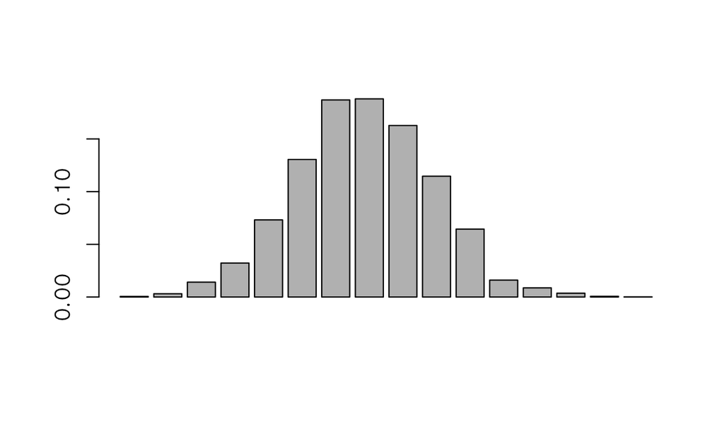

```r
barplot(chest.table$Freq/5738)
```

- 각 막대의 이름은 계급을 나타내는 가슴둘레 값으로 표현할 수 있고, 막대 간의 사이를 띄지 않으며, 디폴트 값으로 주어진 회색 보다는 차라리 백색이 나으므로 이를 설정해 주면,

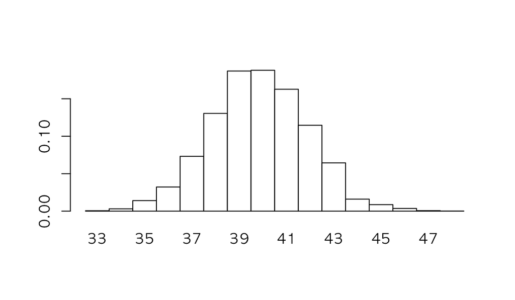

```r
barplot(chest.table$Freq/5738, names.arg=33:48, space=0, col="white")
```

- 확률 히스토그램의 정의에 따라 이 막대들의 면적을 합하면 1이 됨에 유의.

### 기초통계와 표준편차 계산

- 33인치가 3명, 34인치가 18명 등을 한 줄의 긴 벡터로 나타내어야 평균과 표준편차를 쉽게 계산할 수 있으므로 long format으로 바꾸면,

```r
chest.long<-rep(chest.table$Chest, chest.table$Freq)
str(chest.long)
```

```
##  int [1:5738] 33 33 33 34 34 34 34 34 34 34 ...
```

```r
library(reshape2)
melt
```

```
## function (data, ..., na.rm = FALSE, value.name = "value")
## {
##     UseMethod("melt", data)
## }
## <environment: namespace:reshape2>
```

-`chest.long` 을 이용하여 기초통계와 표준편차를 계산하면,

```r
summary(chest.long)
```

```
##    Min. 1st Qu.  Median    Mean 3rd Qu.    Max.
##   33.00   38.00   40.00   39.83   41.00   48.00
```

```r
sd(chest.long)
```

```
## [1] 2.049616
```

## 히스토그램으로 나타내기

- 히스토그램을 직관적으로 그려보면 $y$축은 돗수가 기본값임을 알 수 있음.

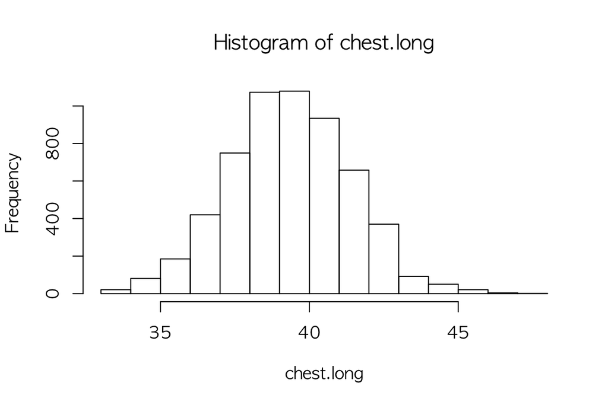

```r
hist(chest.long)
```

- 정규분포와 비교하기 위해서 $y$축을 확률로 나타내려면

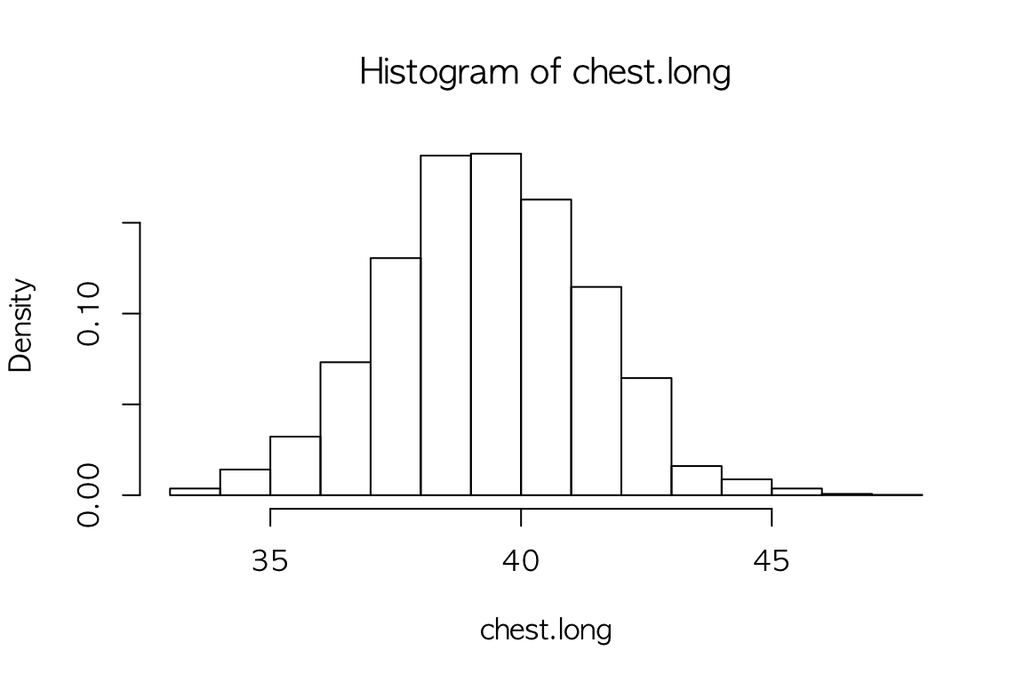

```r
hist(chest.long, prob=TRUE)
```

## 히스토그램의 내부 계산

- 실제로 이 히스토그램을 그리는 데 계산된 값들은?

```r
h.chest<-hist(chest.long, plot=F)
list(breaks=h.chest$breaks, counts=h.chest$counts, density=h.chest$density, mids=h.chest$mids)
```

```
## $breaks
##  [1] 33 34 35 36 37 38 39 40 41 42 43 44 45 46 47 48
##
## $counts
##  [1]   21   81  185  420  749 1073 1079  934  658  370   92   50   21    4
## [15]    1
##
## $density
##  [1] 0.0036598118 0.0141164169 0.0322411990 0.0731962356 0.1305332869
##  [6] 0.1869989543 0.1880446148 0.1627744859 0.1146741025 0.0644823980
## [11] 0.0160334611 0.0087138376 0.0036598118 0.0006971070 0.0001742768
##
## $mids
##  [1] 33.5 34.5 35.5 36.5 37.5 38.5 39.5 40.5 41.5 42.5 43.5 44.5 45.5 46.5
## [15] 47.5
```

- 평균값과 표준편차로부터 히스토그램의 위치가 0.5만큼 왼쪽으로 치우쳐 있다는 것을 알 수 있음. 제자리에 옮겨 놓기 위해서 `breaks` 매개변수를 32.5부터 48.5까지 1간격으로 설정

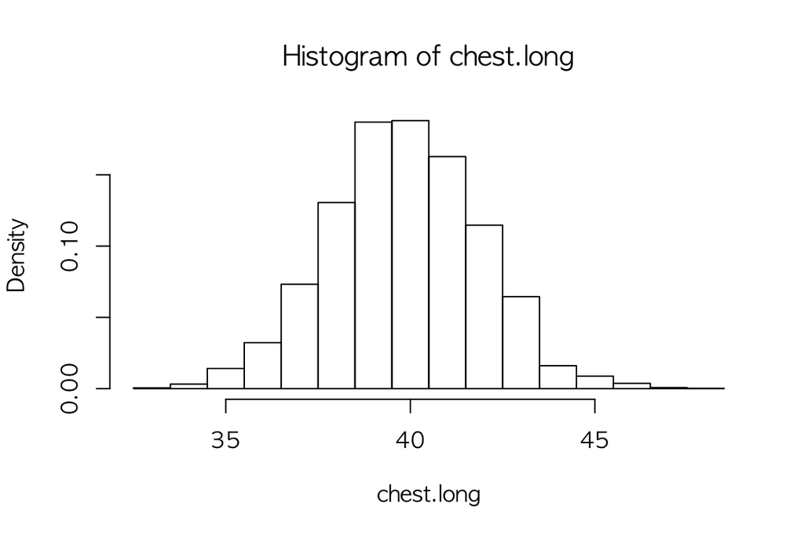

```r
hist(chest.long, prob=TRUE, breaks=32.5:48.5)
```

- 히스토그램을 보기 쉽게 하기 위해서 메인 타이틀과 서브 타이틀, x축 라벨, y축 라벨 설정

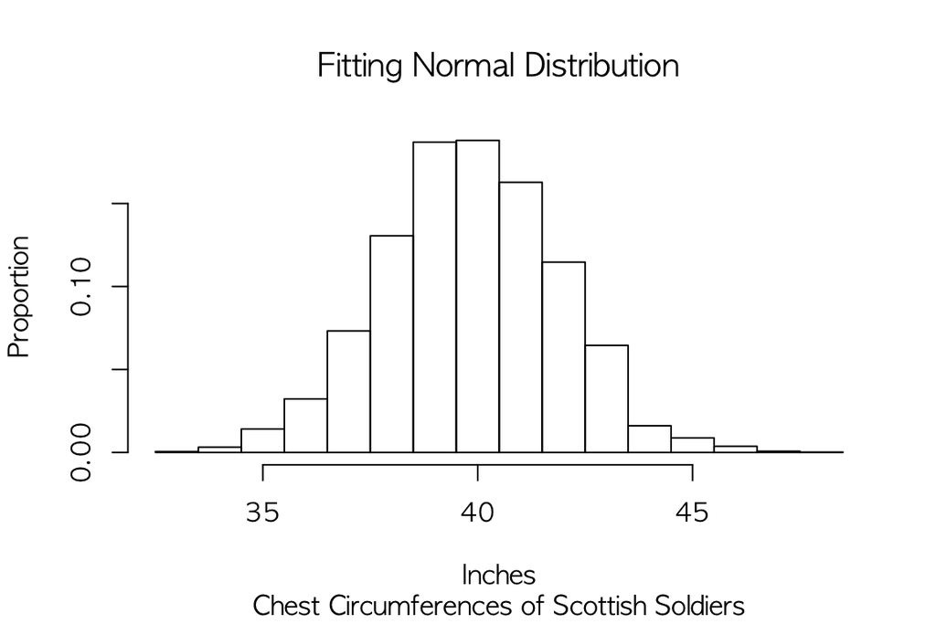

```r
main.title<-"Fitting Normal Distribution"
sub.title<-"Chest Circumferences of Scottish Soldiers"
x.lab<-"Inches"
y.lab<-"Proportion"
hist(chest.long, breaks=32.5:48.5, prob=TRUE, main=main.title, sub=sub.title, xlab=x.lab, ylab=y.lab)
```

## 평균 $\pm$ 표준편차의 의미

- 평균을 중심으로 $\pm$표준편차 만큼 떨어진 자료를 붉은 색 수직점선으로 표시.

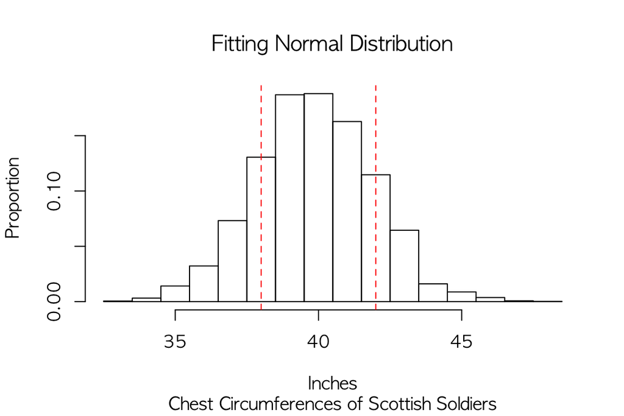

```r
hist(chest.long, breaks=32.5:48.5, prob=T, main=main.title, sub=sub.title, xlab=x.lab, ylab=y.lab)
abline(v=c(38, 42), lty=2, col="red")
```

- 그 사이의 영역을 빗금으로 표시하기 위하여 다각형의 좌표를 계산

```r
h.chest.2<-hist(chest.long, breaks=32.5:48.5, plot=F)
h.chest.2
```

```
## $breaks
##  [1] 32.5 33.5 34.5 35.5 36.5 37.5 38.5 39.5 40.5 41.5 42.5 43.5 44.5 45.5
## [15] 46.5 47.5 48.5
##
## $counts
##  [1]    3   18   81  185  420  749 1073 1079  934  658  370   92   50   21
## [15]    4    1
##
## $density
##  [1] 0.0005228303 0.0031369815 0.0141164169 0.0322411990 0.0731962356
##  [6] 0.1305332869 0.1869989543 0.1880446148 0.1627744859 0.1146741025
## [11] 0.0644823980 0.0160334611 0.0087138376 0.0036598118 0.0006971070
## [16] 0.0001742768
##
## $mids
##  [1] 33 34 35 36 37 38 39 40 41 42 43 44 45 46 47 48
##
## $xname
## [1] "chest.long"
##
## $equidist
## [1] TRUE
##
## attr(,"class")
## [1] "histogram"
```

```r
h.chest.2$density[6:10]
```

```
## [1] 0.1305333 0.1869990 0.1880446 0.1627745 0.1146741
```

```r
y<-h.chest.2$density[6:10]
```

- 5개의 직사각형으로 파악하고 향후 면적 계산을 쉽게 하기 위하여 다음과 같이 좌표 설정

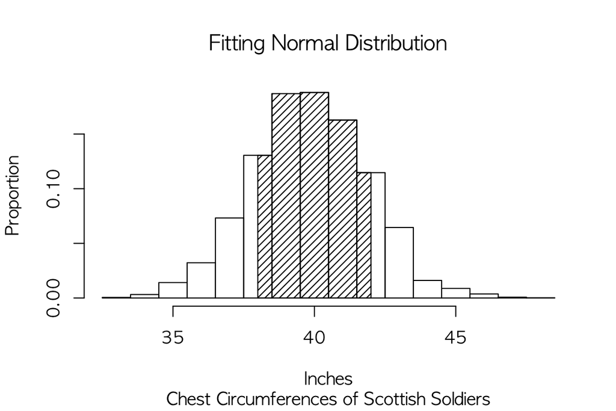

```r
x.coord<-c(38,38.5:41.5,42,42,rep(41.5:38.5,each=2),38,38)
y.coord<-c(rep(0,6),rep(rev(y),each=2),0)
hist(chest.long, breaks=32.5:48.5, prob=TRUE, main=main.title, sub=sub.title, xlab=x.lab, ylab=y.lab)
polygon(x.coord, y.coord, density=20)
```

- 이론적으로 빗금친 부분의 면적은 `pnorm(1)-pnorm(-1)=`0.6826895에 가까울 것으로 예상. 5개의 직사각형의 면적을 구하여 합하는 과정은 다음과 같음.

```r
x.coord[1:6]
```

```
## [1] 38.0 38.5 39.5 40.5 41.5 42.0
```

```r
y
```

```
## [1] 0.1305333 0.1869990 0.1880446 0.1627745 0.1146741
```

```r
diff(x.coord[1:6])
```

```
## [1] 0.5 1.0 1.0 1.0 0.5
```

```r
diff(x.coord[1:6])*y
```

```
## [1] 0.06526664 0.18699895 0.18804461 0.16277449 0.05733705
```

```r
sum(diff(x.coord[1:6])*y)
```

```
## [1] 0.6604217
```

## 정규분포 밀도함수와 비교

- 이론적인 정규분포 밀도함수 곡선을 히스토그램에 덧붙여 그림.

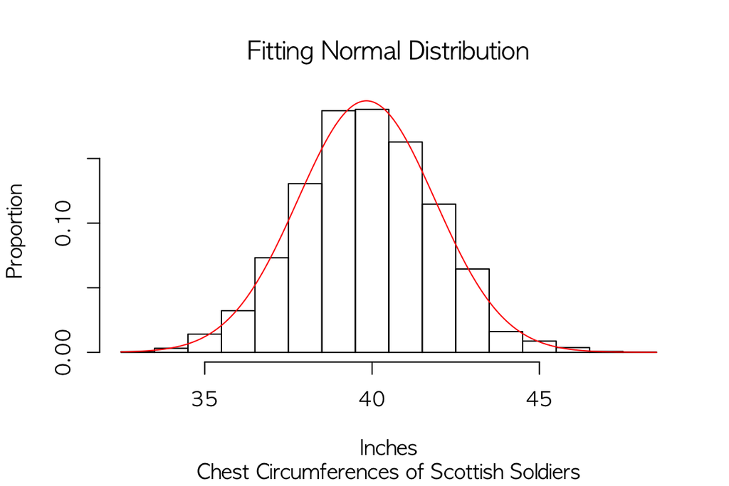

```r
mean.chest<-mean(chest.long)
sd.chest<-sd(chest.long)
x<-seq(32.5,48.5,length=1000)
y.norm<-dnorm(x, mean=mean.chest, sd=sd.chest)
hist(chest.long, breaks=32.5:48.5, prob=TRUE, main=main.title, sub=sub.title, xlab=x.lab, ylab=y.lab)
lines(x, y.norm, col="red")
```

## x축의 눈금 조정

- default로 주어지는 $x$축의 눈금을 제대로 볼 수 있게 고치려면,

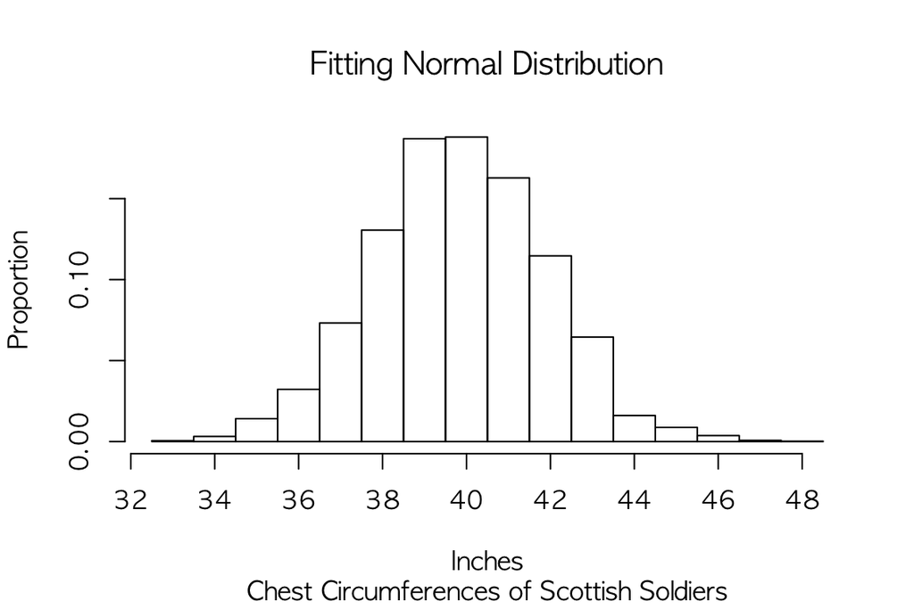

```r
hist(chest.long, breaks=32.5:48.5, prob=TRUE, main=main.title, sub=sub.title, xlab=x.lab, ylab=y.lab, axes=F)
axis(side=1, at=seq(32,48,by=2), labels=paste(seq(32,48, by=2)))
axis(side=2)
```

### ggplot

- data frame으로 변환하여 접근

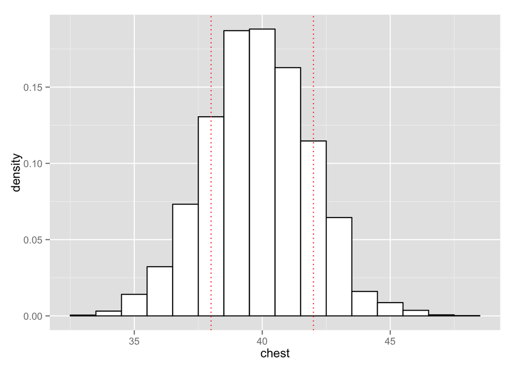

```r
library(ggplot2)
chest.long.df <- data.frame(chest = chest.long)
ggplot(chest.long.df, aes(x = chest)) + geom_histogram(aes(y = ..density..), binwidth=1, breaks = 32.5:48.5, fill = "white", colour = "black") +
  geom_vline(xintercept = c(38, 42), linetype = "dotted", colour = "red")
```